# Intro to R - Data Types and Data Structures - 2

One should look for what is and not what he thinks should be. (Albert Einstein)

# Module completion checklist

| Objective | Complete |
| --- | --- |
| Introduce `vector` and `matrices` and their operations |  |
| Introduce `list` and `dataframe` in R |  |

# Review: basic data structures

| Data structure | Number of dimensions | Single data type | Multiple data types |
| --- | --- | --- | --- |
| Vector (Atomic vector) | 1 (entries) | **✔** | **✘** |
| Vector (List) | 1 (entries) | **✔** | **✔** |
| Matrix | 2 (rows and columns) | **✔** | **✘** |
| Data frame | 2 (rows and columns) | **✔** | **✔** |

# Basic data structures: atomic vectors

```r
# To make an empty vector in R,
# you have a few options:
# Option 1: use `vector()` command.
# The default in R is an empty vector of
# `logical` mode!
vector()
```

```
logical(0)
```

```r
# Option 2: use `c()` command
# (`c` stands for concatenate).
# The default empty vector produced by `c()`
# has a single entry, `NULL`!
c()
```

[output not shown]

- The length of an empty vector will always be **0** since it has no entries in it
- To make a vector out of a given set of character strings, you can wrap them using `c` and separate them with commas

```r
# Make a vector from a set of char. strings
c("My", "name", "is", "Vector")
```

```
[1] "My"     "name"   "is"     "Vector"
```

- To make a vector out of a given set of numbers you can wrap them into a vector `c` and separate them with commas

```r
# Make a vector out of given set of numbers
c(1, 2, 3, 765, -986, 0.5)
```

```
[1]    1.0    2.0    3.0  765.0 -986.0    0.5
```

# Basic data structures: atomic vectors (cont’d)

- Now let’s get some information about a vector

```r
# Create a vector of mode `character` from
# pre-defined set of character strings.
character_vec = c("My", "name", "is", "Vector")
character_vec
```

```
[1] "My"     "name"   "is"     "Vector"
```

```r
# Check if the variable is character.
is.character(character_vec)
```

```
[1] TRUE
```

```r
# Check metadata/attributes of variable.
attributes(character_vec)
```

| Item | Vector |
| --- | --- |
| Value | `character_vec` |
| `typeof()` | character |
| `class()` | character |
| boolean function | `is.character()` |
| `attributes()` | `NULL` |
| `length()` | 4 |

```r
# Check length of variable
# (i.e. how many entries).
length(character_vec)
```

```
[1] 4
```

# Basic data structures: accessing vector values

- Remember that in R, all elements in a data structure correspond to an index of numerical values beginning with **1**

```r
# To access an element inside of the
# vector use `[]` and the index of the element.
character_vec[1]
```

```
[1] "My"
```

```r
# To access multiple elements inside of
# a vector use the start and end indices
# with `:` in-between.
character_vec[1:3]
```

```
[1] "My"   "name" "is"
```

- A special kind of vector in R is a sequence
- Let’s create a sequence and then derive a subset

```r
# Start by creating a sequence of numbers from 1 to 5.
number_seq = seq(from = 1, to = 5, by = 1)
number_seq
```

```
[1] 1 2 3 4 5
```

```r
# Check class.
class(number_seq)
```

```
[1] "numeric"
```

```r
# Subset the first 3 elements.
number_seq[1:3]
```

```
[1] 1 2 3
```

# Basic data structures: operations on vectors

- In R, all arithmetic operations will be carried out **element by element**

```r
number_seq      #<- Let's take our vector.
```

```
[1] 1 2 3 4 5
```

```r
number_seq + 5  #<- Add a number to every entry.
```

```
[1]  6  7  8  9 10
```

```r
number_seq - 5  #<- Subtract a number from every entry.
```

```
[1] -4 -3 -2 -1  0
```

```r
number_seq * 2  #<- Multiply every entry by a number.
```

```
[1]  2  4  6  8 10
```

```r
# To sum all elements use `sum`.
sum(number_seq)
```

```
[1] 15
```

```r
# To multiply all elements use `prod`.
prod(number_seq)
```

```
[1] 120
```

```r
# To get the mean of all vector
# values use `mean`.
mean(number_seq)
```

```
[1] 3
```

```r
# To get the smallest value
# in a vector use `min`.
min(number_seq)
```

```
[1] 1
```

# Basic data structures: why atomic vectors?

- What happens if you mix different types of data inside of an atomic vector?

```r
# Create a vector with entries of different type.
atomic_vec = c(333, "some text", TRUE, NULL)
atomic_vec
```

```
[1] "333"       "some text" "TRUE"
```

```r
# Check class of the resulting vector.
class(atomic_vec)
```

```
[1] "character"
```

- R will cast (i.e. coerce) all elements of that vector to a type/class that can most easily accommodate all elements it contains
- This is why this type of data structure is called atomic, which in computer science is equivalent to homogeneous or unsplittable

# Basic data structures: matrix

- A matrix is a two-dimensional vector
  - It is an array of elements with **2 dimensions** instead of 1
  - Matrix data structures only allow elements of the same type
  - Working with matrices is very similar to working with 1D vectors

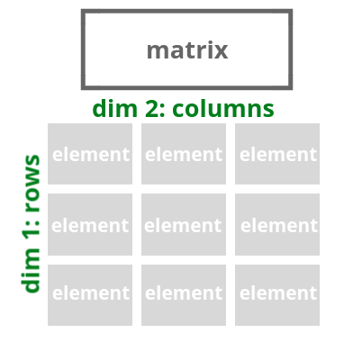

# Basic data structures: working with multiple dimensions

```r
?dim        #<- Check R documentation
dim(object) #<- Any R object
```

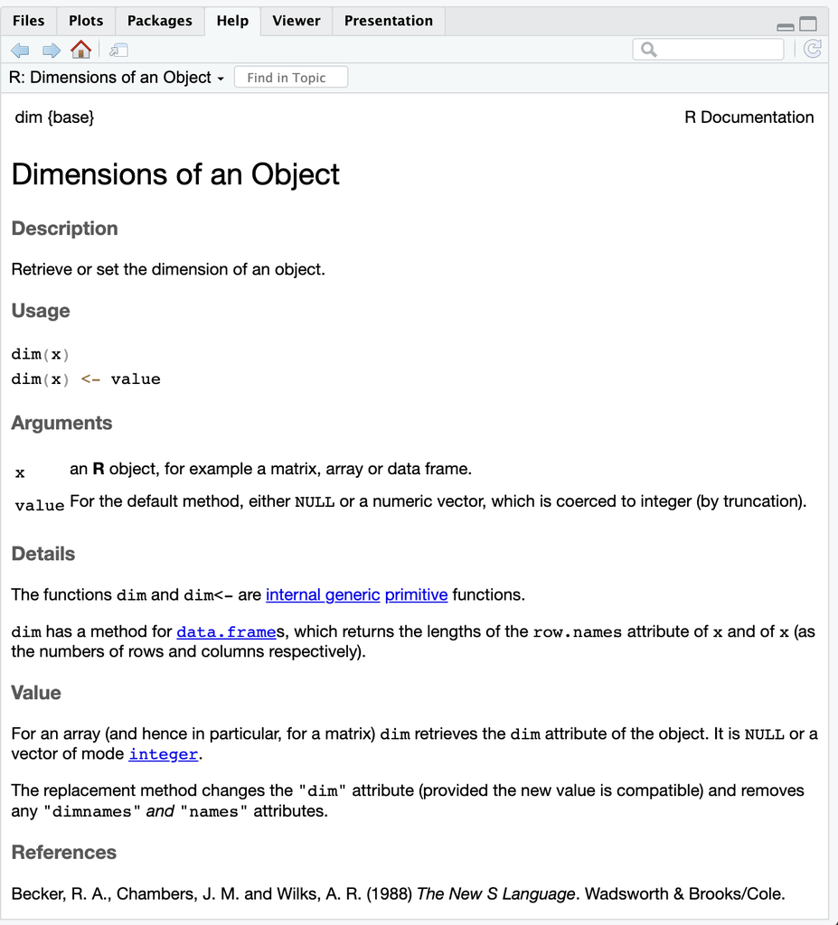

# Basic data structures: making matrices

- Let’s start by creating a matrix with 3 rows and 3 columns

```r
sample_matrix1 = matrix(nrow = 3, #<- n rows
                        ncol = 3) #<- m cols
sample_matrix1
```

```
     [,1] [,2] [,3]
[1,]   NA   NA   NA
[2,]   NA   NA   NA
[3,]   NA   NA   NA
```

```r
# An empty matrix will default to `NA`s.

# Check matrix dimensions.
dim(sample_matrix1)
```

```
[1] 3 3
```

```r
#The `length` command will produce
# the total number of elements in the matrix
# (length = n rows x m cols).
length(sample_matrix1)
```

```
[1] 9
```

- We can also make matrices out of a vector of numbers, like a sequence

```r
sample_matrix2 = 1:9 #<- another way to make
                     #   a sequence of numbers!

# Assign dimensions to matrix:
# 1st number is for rows, 2nd is for columns.
dim(sample_matrix2) = c(3, #<- n rows
                        3) #<- m cols

sample_matrix2
```

```
     [,1] [,2] [,3]
[1,]    1    4    7
[2,]    2    5    8
[3,]    3    6    9
```

```r
# Check matrix dimensions.
dim(sample_matrix2)
```

```
[1] 3 3
```

# Basic data structures: working with matrices

- Again, let’s gather some information about this `sample_matrix1`

```r
# Check type of variable.
typeof(sample_matrix1)
```

```
[1] "logical"
```

```r
# Check class of variable.
class(sample_matrix1)
```

```
[1] "matrix"
```

```r
# Check if the variable of type `integer`.
is.integer(sample_matrix1)
```

```
[1] FALSE
```

```r
# Check metadata/attributes of variable.
attributes(sample_matrix1)
```

```
$dim
[1] 3 3
```

# Basic data structures: operations on matrices

```r
# Let's take a sample matrix.
sample_matrix2
```

```
     [,1] [,2] [,3]
[1,]    1    4    7
[2,]    2    5    8
[3,]    3    6    9
```

```r
# Add a number to every entry.
sample_matrix2 + 5
```

```
     [,1] [,2] [,3]
[1,]    6    9   12
[2,]    7   10   13
[3,]    8   11   14
```

```r
# Multiply every entry by a number.
sample_matrix2 * 2
```

```
     [,1] [,2] [,3]
[1,]    2    8   14
[2,]    4   10   16
[3,]    6   12   18
```

```r
# To sum all elements use `sum`.
sum(sample_matrix2)
```

```
[1] 45
```

```r
# To multiply all elements use `prod`.
prod(sample_matrix2)
```

```
[1] 362880
```

```r
# To get the mean of all matrix
# values use `mean`.
mean(sample_matrix2)
```

```
[1] 5
```

```r
# To get the smallest value
# in a matrix use `min`.
min(sample_matrix2)
```

```
[1] 1
```

# Module completion checklist

| Objective | Complete |
| --- | --- |
| Introduce `vector` and `matrices` and their operations | **✔** |
| Introduce `list` and `dataframe` in R |  |

# Basic data structures: lists

- A list is a collection of entries that act as a container
- Unlike an atomic vector, a list is a generic vector that can hold elements of different types
- A list has a single dimension at its top level, even if it contains elements like matrices
- Lists can be nested, which means that a list can contain elements that are also lists

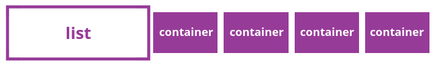

# Basic data structures: lists

- Let’s try creating a list

```r
# To make an empty list in R,
# you have a few options:
# Option 1: use `list()` command.
list()
```

```
list()
```

- We can add elements of different types

```r
# Make a list with different entries.
sample_list = list(1, "am", TRUE)
sample_list
```

```
[[1]]
[1] 1

[[2]]
[1] "am"

[[3]]
[1] TRUE
```

# Basic data structures: naming list elements

- Lists can have attributes such as names
- You can name list elements **when** you create a list

```r
# Create a named list.
sample_list_named = list(One = 1,
                         Two = "am",
                         Three = TRUE)
sample_list_named
```

```
$One
[1] 1

$Two
[1] "am"

$Three
[1] TRUE
```

```r
attributes(sample_list_named)
```

```
$names
[1] "One"   "Two"   "Three"
```

- You can also set element names **after** the list has been created

```r
# Name existing list.
names(sample_list) = c("One", "Two", "Three")
sample_list
```

```
$One
[1] 1

$Two
[1] "am"

$Three
[1] TRUE
```

```r
attributes(sample_list)
```

```
$names
[1] "One"   "Two"   "Three"
```

# Basic data structures: introducing structure

```r
?str        #<- Check R documentation
str(object) #<- Any R object
```

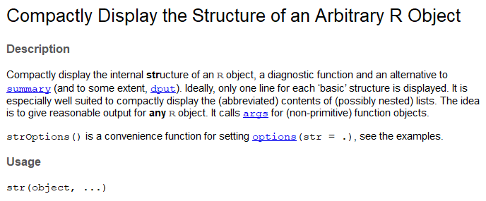

```r
# Inspect the list's structure.
str(sample_list)
```

```
List of 3
 $ One  : num 1
 $ Two  : chr "am"
 $ Three: logi TRUE
```

- The command `str()` lets you inspect the structure of any R object such as a list or a dataframe
- It returns:
  - The `class` of the object (e.g. `List`)
  - The `length` of the object (e.g. `3`)
  - Snippet of each entry and its `type` (e.g. `One: num 1`, `Two: chr "am"`, `Three: logi TRUE`)

# Basic data structures: accessing data within lists

- To access an element in a list, you can use its index

```r
# Access an element of a list.
sample_list[[2]]
```

```
[1] "am"
```

```r
# Access a sub-list with its element(s).
sample_list[2]
```

```
$Two
[1] "am"
```

```r
# Access a sub-list with its element(s).
sample_list[2:3]
```

```
$Two
[1] "am"

$Three
[1] TRUE
```

- You can also refer to an element by its name, using the `$` operator (as seen in the output of the `str` command)

```r
# Access named list elements.
sample_list$One
```

```
[1] 1
```

```r
sample_list$Two
```

```
[1] "am"
```

```r
sample_list$Three
```

```
[1] TRUE
```

# Basic data structures: single vs. double brackets

- When using an index to access or replace values in a data structure, we use different configurations of **brackets [ ]** for different levels of granularity
- Single brackets [ ] extract a subset of a list
  - Since lists can nest, that subset might actually be a list containing multiple elements
- Double brackets [[ ]] extract a single element from a list

[figure not shown]

# Basic data structures: dataframes

- A dataframe is a special kind of list arranged in a 2D structure
- Each element in a list is a column with the same number of entries
- Different columns can be of different types (e.g. `character`, `numeric`, `logical`)
- Each entry within a given column should be of the same type
- Dataframes are what we generally think of as the “standard” data structure, like a table in which
  - Columns are vectors
  - Rows are lists

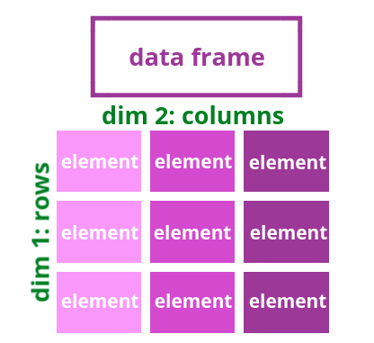

# Basic data structures: making dataframes

- As with vectors, matrices, and lists, a dataframe can be created empty

```r
# To make an empty dataframe in R,
# use `data.frame()` command.
data.frame()
```

```
data frame with 0 columns and 0 rows
```

```r
# To make a dataframe with several
# columns, pass column values
# to the `data.frame()` command just like
# you would do with lists.
data.frame(1:5, 6:10)
```

```
  X1.5 X6.10
1    1     6
2    2     7
3    3     8
4    4     9
5    5    10
```

- Note that without defined column names, `data.frame` auto-generates them
  - Column names in R cannot have **numbers** as their first character, which is why R adds an `X` to the head
- You can also combine pre-existing vectors into a dataframe

# Dataframes: converting a matrix

- We can cast a `matrix` into a `data.frame` with `as.data.frame()` command

```r
# Make a dataframe from matrix.
sample_matrix1 = matrix(nrow = 3, ncol = 3)
sample_matrix1 = 1:9
dim(sample_matrix1) = c(3, 3)

sample_df1 = as.data.frame(sample_matrix1)
sample_df1
```

```
  V1 V2 V3
1  1  4  7
2  2  5  8
3  3  6  9
```

```r
# Make a dataframe from matrix with named columns and rows.
sample_df2 = as.data.frame(sample_matrix1, row.names = c('Row1','Row2','Row3'))
cols = c('Col1','Col2','Col3') # defining the column names
colnames(sample_df2) = cols   # assigning the column names to df
sample_df2
```

```
     Col1 Col2 Col3
Row1    1    4    7
Row2    2    5    8
Row3    3    6    9
```

# Dataframes: selecting columns

- Let’s explore the different methods we have learned so far for selecting columns from a dataframe
  - Use `$column_name`
  - Use `[[column_index]]`
  - Use `[ , column_index]`

```r
# To access a column of a dataframe
# Option 1: Use `$column_name`.
sample_df2$Col1
```

```
[1] 1 2 3
```

```r
# To access a column of a dataframe
# Option 2: Use `[[column_index]]`.
sample_df2[[1]]
```

```
[1] 1 2 3
```

```r
# To access a column of a dataframe
# Option 3: Use `[ , column_index]`.
sample_df2[, 1]
```

```
[1] 1 2 3
```

# Dataframes: subsetting rows

- And now, let’s try selecting a row from a dataframe
  - Use `[row_index, ]`
  - Use `["row_name", ]`

```r
# To access a row of a dataframe
# Option 1: use `[row_index, ]`.
sample_df2[1, ]
```

```
     Col1 Col2 Col3
Row1    1    4    7
```

```r
# To access a row of a dataframe
# Option 2: use `["row_name", ]`.
sample_df2["Row1", ]
```

```
     Col1 Col2 Col3
Row1    1    4    7
```

# Dataframes: accessing individual values

- There are four common methods for accessing individual values within a dataframe, but they use different attributes
- Option 1: `$column_name[row_index]`
- Option 2: `[[column_index]][row_index]`
- Option 3: `[row_index, column_index]`
- Option 4: `["row_name", "column_name"]`

```r
# Option 1:
# `data_frame$column_name[row_index]`
sample_df2$Col2[1]
```

```
[1] 4
```

```r
# Option 2:
# `data_frame[[column_index]][row_index]`
sample_df2[[2]][1]
```

```
[1] 4
```

```r
# Option 3:
# `data_frame[row_index, column_index]`
sample_df2[1, 2]
```

```
[1] 4
```

```r
# Option 4:
# `data_frame["row_name", "column_name"]`
sample_df2["Row1", "Col2"]
```

```
[1] 4
```

# Knowledge check

# Exercise

You are now ready to try Tasks 4-12 in the Exercise for this topic

# Module completion checklist

| Objective | Complete |
| --- | --- |
| Introduce `vector` and `matrices` and their operations | **✔** |
| Introduce `list` and `dataframe` in R | **✔** |

# Data Types and Data Structures: Topic summary

In this part of the course, we have covered:

- Overview of R data types and data structures
- Lists, vectors, matrices, and dataframes

# Congratulations on completing this module!